# Cars4U_Project-2

Objective: To explore and visualize the dataset, build a linear regression model to predict the prices of used cars, and generate a set of insights and recommendations that will help the business.

Data Description: The data contains the different attributes of used cars sold in different locations. The detailed data dictionary is given below.

Data Dictionary:

S.No.: Serial number

Name: Name of the car which includes brand name and model name

Location: Location in which the car is being sold or is available for purchase (cities)

Year: Manufacturing year of the car

Kilometers_driven: The total kilometers driven in the car by the previous owner(s) in km

Fuel_Type: The type of fuel used by the car (Petrol, Diesel, Electric, CNG, LPG)

Transmission: The type of transmission used by the car (Automatic/Manual)

Owner: Type of ownership

Mileage: The standard mileage offered by the car company in kmpl or km/kg

Engine: The displacement volume of the engine in CC

Power: The maximum power of the engine in bhp

Seats: The number of seats in the car

New_Price: The price of a new car of the same model in INR Lakhs (1 Lakh INR = 100,000 INR)

Price: The price of the used car in INR Lakhs

# 1. Loading libraries

```python
import pandas as pd
import numpy as np

import matplotlib.pyplot as plt
import seaborn as sns

# Removes the limit from the number of displayed columns and rows.
# This is so I can see the entire dataframe when I print it
pd.set_option('display.max_columns', None)
# pd.set_option('display.max_rows', None)
pd.set_option('display.max_rows', 200)

# let colab access my google drive
#from google.colab import drive
#drive.mount('/content/drive')
```

# 2. Loading and exploring the data

In this section the goals are to load the data into python and then to check its basic properties. This will include the dimension, column types and names, and missingness counts.

```python
#df = pd.read_csv("/content/drive/MyDrive/used_cars_data.csv", index_col=0)
df = pd.read_csv("used_cars_data.csv", index_col=0)
print(f'There are {df.shape[0]} rows and {df.shape[1]} columns.')  # f-string

# I'm now going to look at 10 random rows
# I'm setting the random seed via np.random.seed so that
# I get the same random results every time
np.random.seed(1)
df.sample(n=10)
```

```
There are 7253 rows and 13 columns.
```

| S.No. | Name | Location | Year | Kilometers_Driven | Fuel_Type | Transmission | Owner_Type | Mileage | Engine | Power | Seats | New_Price | Price |
| --- | --- | --- | --- | --- | --- | --- | --- | --- | --- | --- | --- | --- | --- |
| 2397 | Ford EcoSport 1.5 Petrol Trend | Kolkata | 2016 | 21460 | Petrol | Manual | First | 17.0 kmpl | 1497 CC | 121.36 bhp | 5.0 | 9.47 | 6.00 |
| 3777 | Maruti Wagon R VXI 1.2 | Kochi | 2015 | 49818 | Petrol | Manual | First | 21.5 kmpl | 1197 CC | 81.80 bhp | 5.0 | 5.44 | 4.11 |
| 4425 | Ford Endeavour 4x2 XLT | Hyderabad | 2007 | 130000 | Diesel | Manual | First | 13.1 kmpl | 2499 CC | 141 bhp | 7.0 | 35.29 | 6.00 |
| 3661 | Mercedes-Benz E-Class E250 CDI Avantgrade | Coimbatore | 2016 | 39753 | Diesel | Automatic | First | 13.0 kmpl | 2143 CC | 201.1 bhp | 5.0 | 86.97 | 35.28 |
| 4514 | Hyundai Xcent 1.2 Kappa AT SX Option | Kochi | 2016 | 45560 | Petrol | Automatic | First | 16.9 kmpl | 1197 CC | 82 bhp | 5.0 | 8.23 | 6.34 |
| 599 | Toyota Innova Crysta 2.8 ZX AT | Coimbatore | 2019 | 40674 | Diesel | Automatic | First | 11.36 kmpl | 2755 CC | 171.5 bhp | 7.0 | 28.05 | 24.82 |
| 186 | Mercedes-Benz E-Class E250 CDI Avantgrade | Bangalore | 2014 | 37382 | Diesel | Automatic | First | 13.0 kmpl | 2143 CC | 201.1 bhp | 5.0 | 86.97 | 32.00 |
| 305 | Audi A6 2011-2015 2.0 TDI Premium Plus | Kochi | 2014 | 61726 | Diesel | Automatic | First | 17.68 kmpl | 1968 CC | 174.33 bhp | 5.0 | 67.10 | 20.77 |
| 4582 | Hyundai i20 1.2 Magna | Kolkata | 2011 | 36000 | Petrol | Manual | First | 18.5 kmpl | 1197 CC | 80 bhp | 5.0 | 10.25 | 2.50 |
| 5434 | Honda WR-V Edge Edition i-VTEC S | Kochi | 2019 | 13913 | Petrol | Manual | First | 17.5 kmpl | 1199 CC | 88.7 bhp | 5.0 | 9.36 | 8.20 |

```python
df.info()  # data types
```

```
<class 'pandas.core.frame.DataFrame'>
Int64Index: 7253 entries, 0 to 7252
Data columns (total 13 columns):
 #   Column             Non-Null Count  Dtype
---  ------             --------------  -----
 0   Name               7253 non-null   object
 1   Location           7253 non-null   object
 2   Year               7253 non-null   int64
 3   Kilometers_Driven  7253 non-null   int64
 4   Fuel_Type          7253 non-null   object
 5   Transmission       7253 non-null   object
 6   Owner_Type         7253 non-null   object
 7   Mileage            7251 non-null   object
 8   Engine             7207 non-null   object
 9   Power              7078 non-null   object
 10  Seats              7200 non-null   float64
 11  New_Price          7253 non-null   float64
 12  Price              6019 non-null   float64
dtypes: float64(3), int64(2), object(8)
memory usage: 793.3+ KB
```

```python
# looking at which columns have the most missing values
df.isnull().sum().sort_values(ascending=False)
```

```
Price                1234
Power                 175
Seats                  53
Engine                 46
Mileage                 2
Name                    0
Location                0
Year                    0
Kilometers_Driven       0
Fuel_Type               0
Transmission            0
Owner_Type              0
New_Price               0
dtype: int64
```

Price has the maximum number of missing values followed by power, seats, engine & mileage. Rest of the columns have no missing values.

```python
df['Mileage'] = df['Mileage'].str.extract('(\d+)', expand=False).astype(float)
df['Engine'] = df['Engine'].str.extract('(\d+)', expand=False).astype(float)
df['Power'] = df['Power'].str.extract('(\d+)', expand=False).astype(float)
```

Convert Mileage, Engine, Power to float by removing trailing unit/string characters

```python
df.sample(n=10) # Check data sample again for succesful conversion
```

| S.No. | Name | Location | Year | Kilometers_Driven | Fuel_Type | Transmission | Owner_Type | Mileage | Engine | Power | Seats | New_Price | Price |
| --- | --- | --- | --- | --- | --- | --- | --- | --- | --- | --- | --- | --- | --- |
| 2245 | Maruti Wagon R VXI 1.2 | Mumbai | 2015 | 55000 | Petrol | Manual | First | 21.0 | 1197.0 | 81.0 | 5.0 | 5.88 | 3.10 |
| 6407 | Maruti Swift LXI Option | Kochi | 2017 | 62889 | Petrol | Manual | First | 20.0 | 1197.0 | 81.0 | 5.0 | 7.88 | NaN |
| 1226 | Toyota Corolla Altis 1.8 VL CVT | Delhi | 2017 | 21000 | Petrol | Automatic | First | 14.0 | 1798.0 | 138.0 | 5.0 | 23.25 | 18.00 |
| 533 | Honda City 1.5 V AT | Mumbai | 2010 | 69000 | Petrol | Automatic | Second | 16.0 | 1497.0 | 118.0 | 5.0 | 13.58 | 2.85 |
| 6330 | Hyundai i20 Asta 1.2 | Kolkata | 2015 | 33000 | Petrol | Manual | First | 18.0 | 1197.0 | 81.0 | 5.0 | 10.25 | NaN |
| 5931 | Maruti Ertiga VXI | Mumbai | 2012 | 52500 | Petrol | Manual | Second | 16.0 | 1373.0 | 93.0 | 7.0 | 11.27 | 5.25 |
| 2784 | Nissan Micra Diesel XV | Hyderabad | 2011 | 86732 | Diesel | Manual | First | 23.0 | 1461.0 | 63.0 | 5.0 | 9.47 | 3.60 |
| 5180 | Skoda Superb Elegance 1.8 TSI AT | Bangalore | 2009 | 75000 | Petrol | Automatic | Second | 13.0 | 1798.0 | 157.0 | 5.0 | 33.36 | 4.95 |
| 2722 | Volkswagen Ameo 1.5 TDI Highline | Kochi | 2018 | 31426 | Diesel | Manual | First | 21.0 | 1498.0 | 108.0 | 5.0 | 9.72 | 7.90 |
| 5322 | Hyundai Grand i10 CRDi Sportz | Ahmedabad | 2016 | 30000 | Diesel | Manual | First | 24.0 | 1120.0 | 70.0 | 5.0 | 7.45 | 5.50 |

```python
df.info() # check data type again
```

```
<class 'pandas.core.frame.DataFrame'>
Int64Index: 7253 entries, 0 to 7252
Data columns (total 13 columns):
 #   Column             Non-Null Count  Dtype
---  ------             --------------  -----
 0   Name               7253 non-null   object
 1   Location           7253 non-null   object
 2   Year               7253 non-null   int64
 3   Kilometers_Driven  7253 non-null   int64
 4   Fuel_Type          7253 non-null   object
 5   Transmission       7253 non-null   object
 6   Owner_Type         7253 non-null   object
 7   Mileage            7251 non-null   float64
 8   Engine             7207 non-null   float64
 9   Power              7078 non-null   float64
 10  Seats              7200 non-null   float64
 11  New_Price          7253 non-null   float64
 12  Price              6019 non-null   float64
dtypes: float64(6), int64(2), object(5)
memory usage: 793.3+ KB
```

Now there are 8 numerical column and 5 categorical column in total.

```python
df.describe()
```

|  | Year | Kilometers_Driven | Mileage | Engine | Power | Seats | New_Price | Price |
| --- | --- | --- | --- | --- | --- | --- | --- | --- |
| count | 7253.000000 | 7.253000e+03 | 7251.000000 | 7207.000000 | 7078.000000 | 7200.000000 | 7253.000000 | 6019.000000 |
| mean | 2013.365366 | 5.869906e+04 | 17.717694 | 1616.573470 | 112.448714 | 5.279722 | 21.307322 | 9.479468 |
| std | 3.254421 | 8.442772e+04 | 4.559841 | 595.285137 | 53.534115 | 0.811660 | 24.256314 | 11.187917 |
| min | 1996.000000 | 1.710000e+02 | 0.000000 | 72.000000 | 34.000000 | 0.000000 | 3.910000 | 0.440000 |
| 25% | 2011.000000 | 3.400000e+04 | 15.000000 | 1198.000000 | 75.000000 | 5.000000 | 7.880000 | 3.500000 |
| 50% | 2014.000000 | 5.341600e+04 | 18.000000 | 1493.000000 | 94.000000 | 5.000000 | 11.300000 | 5.640000 |
| 75% | 2016.000000 | 7.300000e+04 | 21.000000 | 1968.000000 | 138.000000 | 5.000000 | 21.690000 | 9.950000 |
| max | 2019.000000 | 6.500000e+06 | 33.000000 | 5998.000000 | 616.000000 | 10.000000 | 375.000000 | 160.000000 |

### 2.1 Univariate Analysis

**Let's check the distribution for numerical columns.**

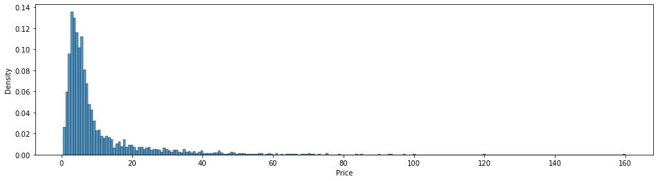

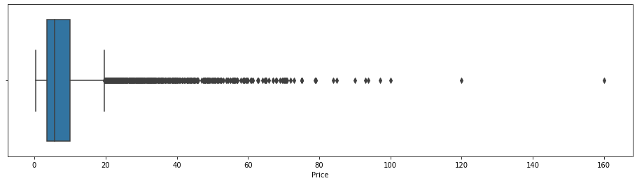

```python
sns.histplot(data=df,x='Price',stat='density')
plt.show()
sns.boxplot(data=df,x='Price')
plt.show()
```

Price data is right skewed and have many outliers. So, it shouldn't be trimmed as it can be genuine data.

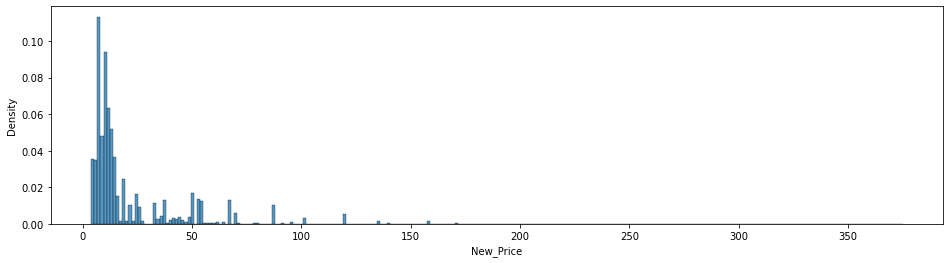

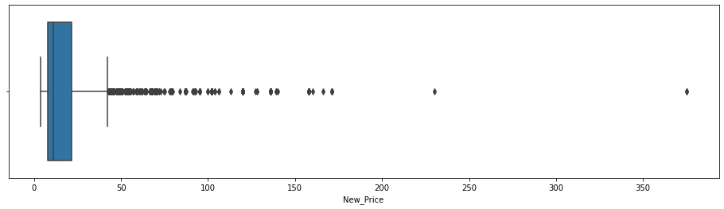

```python
sns.histplot(data=df,x='New_Price',stat='density')
plt.show()
sns.boxplot(data=df,x='New_Price')
plt.show()
```

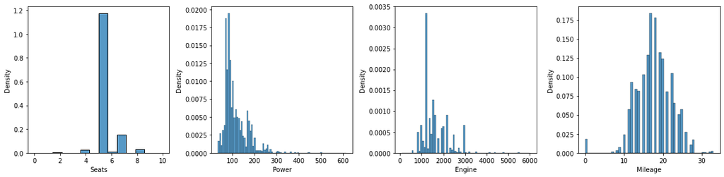

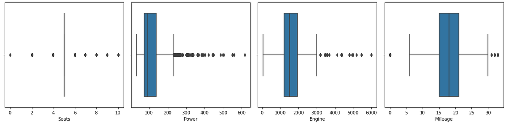

```python
plt.rcParams['figure.figsize'] = [16, 4]
plt.subplot(1,4,1)
sns.histplot(data=df,x='Seats',stat='density')
plt.subplot(1,4,2)
sns.histplot(data=df,x='Power',stat='density')
plt.subplot(1,4,3)
sns.histplot(data=df,x='Engine',stat='density')
plt.subplot(1,4,4)
sns.histplot(data=df,x='Mileage',stat='density')
plt.tight_layout()
plt.show()

plt.rcParams['figure.figsize'] = [16, 4]
plt.subplot(1,4,1)
sns.boxplot(data=df,x='Seats')
plt.subplot(1,4,2)
sns.boxplot(data=df,x='Power')
plt.subplot(1,4,3)
sns.boxplot(data=df,x='Engine')
plt.subplot(1,4,4)
sns.boxplot(data=df,x='Mileage')
plt.tight_layout()
plt.show()
```

- Majority of the vehicles have 5 number of seats
- Both engine power & Engine volume has wide variation with many outliers
- Mileage has a mean of 18.0 with very few outliers.

### 2.2 Bivariate Analysis

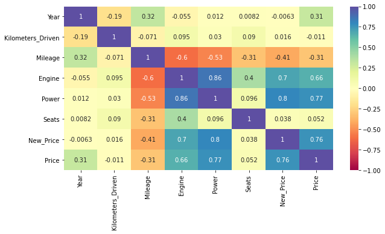

```python
plt.figure(figsize=(10,5))
sns.heatmap(df.corr(),annot=True,cmap='Spectral',vmin=-1,vmax=1)
plt.show()
```

- Used car price has the highest positiv corrlation with power followed by new car price and engine size.
- Year, Mileage and kilometers_driven has lower correlation.

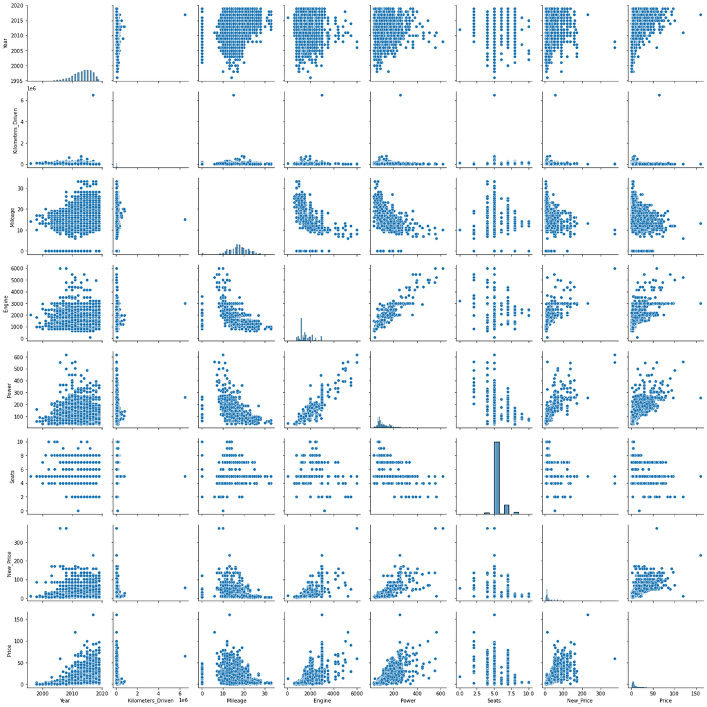

```python
sns.pairplot(df)
```

# 3. Processing the data

### 3.1 Dropping Outliers

Kiometers driven has a outlier and it would be better to drop it.

```python
df.drop(df[df['Kilometers_Driven'] > 2e6].index, inplace = True)
```

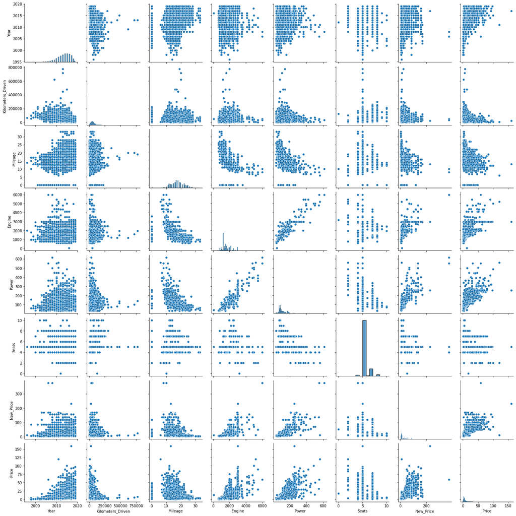

```python
sns.pairplot(df)
```

### 3.2 Treat Missing Values

```python
df['Price'].fillna(df['Price'].mean(), inplace=True)
df['Power'].fillna(df['Power'].mean(), inplace=True)
df['Seats'].fillna(df['Seats'].mean(), inplace=True)
df['Engine'].fillna(df['Engine'].mean(), inplace=True)
df['Mileage'].fillna(df['Mileage'].mean(), inplace=True)
df.info()
```

```
<class 'pandas.core.frame.DataFrame'>
Int64Index: 7252 entries, 0 to 7252
Data columns (total 13 columns):
 #   Column             Non-Null Count  Dtype
---  ------             --------------  -----
 0   Name               7252 non-null   object
 1   Location           7252 non-null   object
 2   Year               7252 non-null   int64
 3   Kilometers_Driven  7252 non-null   int64
 4   Fuel_Type          7252 non-null   object
 5   Transmission       7252 non-null   object
 6   Owner_Type         7252 non-null   object
 7   Mileage            7252 non-null   float64
 8   Engine             7252 non-null   float64
 9   Power              7252 non-null   float64
 10  Seats              7252 non-null   float64
 11  New_Price          7252 non-null   float64
 12  Price              7252 non-null   float64
dtypes: float64(6), int64(2), object(5)
memory usage: 793.2+ KB
```

### 3.3 Categorical Categories Treatment

**Find Unique Values in all categories**

```python
df['Name'].nunique()
```

```
2041
```

Too many name entries to make separate columns

```python
p_loc = df['Location'].nunique()
p_fuel = df['Fuel_Type'].nunique()
p_trans = df['Transmission'].nunique()
p_own = df['Owner_Type'].nunique()
print(p_loc,p_fuel,p_trans,p_own)
```

```
11 5 2 4
```

```python
df = pd.get_dummies(df, columns=['Location', 'Fuel_Type','Transmission','Owner_Type'],drop_first=True)
```

```python
df
```

| S.No. | Name | Year | Kilometers_Driven | Mileage | Engine | Power | Seats | New_Price | Price | Location_Bangalore | Location_Chennai | Location_Coimbatore | Location_Delhi | Location_Hyderabad | Location_Jaipur | Location_Kochi | Location_Kolkata | Location_Mumbai | Location_Pune | Fuel_Type_Diesel | Fuel_Type_Electric | Fuel_Type_LPG | Fuel_Type_Petrol | Transmission_Manual | Owner_Type_Fourth & Above | Owner_Type_Second | Owner_Type_Third |
| --- | --- | --- | --- | --- | --- | --- | --- | --- | --- | --- | --- | --- | --- | --- | --- | --- | --- | --- | --- | --- | --- | --- | --- | --- | --- | --- | --- |
| 0 | Maruti Wagon R LXI CNG | 2010 | 72000 | 26.0 | 998.0 | 58.0 | 5.0 | 5.51 | 1.750000 | 0 | 0 | 0 | 0 | 0 | 0 | 0 | 0 | 1 | 0 | 0 | 0 | 0 | 0 | 1 | 0 | 0 | 0 |
| 1 | Hyundai Creta 1.6 CRDi SX Option | 2015 | 41000 | 19.0 | 1582.0 | 126.0 | 5.0 | 16.06 | 12.500000 | 0 | 0 | 0 | 0 | 0 | 0 | 0 | 0 | 0 | 1 | 1 | 0 | 0 | 0 | 1 | 0 | 0 | 0 |
| 2 | Honda Jazz V | 2011 | 46000 | 18.0 | 1199.0 | 88.0 | 5.0 | 8.61 | 4.500000 | 0 | 1 | 0 | 0 | 0 | 0 | 0 | 0 | 0 | 0 | 0 | 0 | 0 | 1 | 1 | 0 | 0 | 0 |
| 3 | Maruti Ertiga VDI | 2012 | 87000 | 20.0 | 1248.0 | 88.0 | 7.0 | 11.27 | 6.000000 | 0 | 1 | 0 | 0 | 0 | 0 | 0 | 0 | 0 | 0 | 1 | 0 | 0 | 0 | 1 | 0 | 0 | 0 |
| 4 | Audi A4 New 2.0 TDI Multitronic | 2013 | 40670 | 15.0 | 1968.0 | 140.0 | 5.0 | 53.14 | 17.740000 | 0 | 0 | 1 | 0 | 0 | 0 | 0 | 0 | 0 | 0 | 1 | 0 | 0 | 0 | 0 | 0 | 1 | 0 |
| ... | ... | ... | ... | ... | ... | ... | ... | ... | ... | ... | ... | ... | ... | ... | ... | ... | ... | ... | ... | ... | ... | ... | ... | ... | ... | ... | ... |
| 7248 | Volkswagen Vento Diesel Trendline | 2011 | 89411 | 20.0 | 1598.0 | 103.0 | 5.0 | 13.23 | 9.470243 | 0 | 0 | 0 | 0 | 1 | 0 | 0 | 0 | 0 | 0 | 1 | 0 | 0 | 0 | 1 | 0 | 0 | 0 |
| 7249 | Volkswagen Polo GT TSI | 2015 | 59000 | 17.0 | 1197.0 | 103.0 | 5.0 | 10.15 | 9.470243 | 0 | 0 | 0 | 0 | 0 | 0 | 0 | 0 | 1 | 0 | 0 | 0 | 0 | 1 | 0 | 0 | 0 | 0 |
| 7250 | Nissan Micra Diesel XV | 2012 | 28000 | 23.0 | 1461.0 | 63.0 | 5.0 | 9.47 | 9.470243 | 0 | 0 | 0 | 0 | 0 | 0 | 0 | 1 | 0 | 0 | 1 | 0 | 0 | 0 | 1 | 0 | 0 | 0 |
| 7251 | Volkswagen Polo GT TSI | 2013 | 52262 | 17.0 | 1197.0 | 103.0 | 5.0 | 10.15 | 9.470243 | 0 | 0 | 0 | 0 | 0 | 0 | 0 | 0 | 0 | 1 | 0 | 0 | 0 | 1 | 0 | 0 | 0 | 1 |
| 7252 | Mercedes-Benz E-Class 2009-2013 E 220 CDI Avan... | 2014 | 72443 | 10.0 | 2148.0 | 170.0 | 5.0 | 86.97 | 9.470243 | 0 | 0 | 0 | 0 | 0 | 0 | 1 | 0 | 0 | 0 | 1 | 0 | 0 | 0 | 0 | 0 | 0 | 0 |

7252 rows × 27 columns

```python
df.info()
```

```
<class 'pandas.core.frame.DataFrame'>
Int64Index: 7252 entries, 0 to 7252
Data columns (total 27 columns):
 #   Column                     Non-Null Count  Dtype
---  ------                     --------------  -----
 0   Name                       7252 non-null   object
 1   Year                       7252 non-null   int64
 2   Kilometers_Driven          7252 non-null   int64
 3   Mileage                    7252 non-null   float64
 4   Engine                     7252 non-null   float64
 5   Power                      7252 non-null   float64
 6   Seats                      7252 non-null   float64
 7   New_Price                  7252 non-null   float64
 8   Price                      7252 non-null   float64
 9   Location_Bangalore         7252 non-null   uint8
```

[output cut: 19 more lines]

```python
df['Make'] = df['Name'].str.split(' ').str.get(0) # Use name column - make
#df['Model'] = df['Name'].str.split(' ').str.get(1) # Use name column - model
df.drop('Name',axis=1,inplace=True)
```

```python
p_make = df['Make'].nunique()
#p_model = df['Model'].nunique()
#print(p_make,p_model)
```

```python
df = pd.get_dummies(df, columns=['Make'],drop_first=True)
```

```python
df.info()
```

```
<class 'pandas.core.frame.DataFrame'>
Int64Index: 7252 entries, 0 to 7252
Data columns (total 58 columns):
 #   Column                     Non-Null Count  Dtype
---  ------                     --------------  -----
 0   Year                       7252 non-null   int64
 1   Kilometers_Driven          7252 non-null   int64
 2   Mileage                    7252 non-null   float64
 3   Engine                     7252 non-null   float64
 4   Power                      7252 non-null   float64
 5   Seats                      7252 non-null   float64
 6   New_Price                  7252 non-null   float64
 7   Price                      7252 non-null   float64
 8   Location_Bangalore         7252 non-null   uint8
 9   Location_Chennai           7252 non-null   uint8
```

[output cut: 50 more lines]

Total 58 columns by expanding categorical columns.

With this, dataframe is all set for further regression analysis

# 4. Model Building

```python
df.describe().T  # quick summary of numeric features
```

|  | count | mean | std | min | 25% | 50% | 75% | max |
| --- | --- | --- | --- | --- | --- | --- | --- | --- |
| Year | 7252.0 | 2013.364865 | 3.254365 | 1996.00 | 2011.00 | 2014.00 | 2016.000000 | 2019.0 |
| Kilometers_Driven | 7252.0 | 57810.852868 | 37499.537277 | 171.00 | 34000.00 | 53404.00 | 73000.000000 | 775000.0 |
| Mileage | 7252.0 | 17.718069 | 4.559415 | 0.00 | 15.00 | 18.00 | 21.000000 | 33.0 |
| Engine | 7252.0 | 1616.382459 | 593.214866 | 72.00 | 1198.00 | 1493.00 | 1968.000000 | 5998.0 |
| Power | 7252.0 | 112.428148 | 52.860261 | 34.00 | 77.00 | 98.00 | 138.000000 | 616.0 |
| Seats | 7252.0 | 5.279761 | 0.808737 | 0.00 | 5.00 | 5.00 | 5.000000 | 10.0 |
| New_Price | 7252.0 | 21.302666 | 24.254745 | 3.91 | 7.88 | 11.30 | 21.457500 | 375.0 |
| Price | 7252.0 | 9.470243 | 10.171519 | 0.44 | 3.85 | 6.75 | 9.470243 | 160.0 |
| Location_Bangalore | 7252.0 | 0.060673 | 0.238746 | 0.00 | 0.00 | 0.00 | 0.000000 | 1.0 |
| Location_Chennai | 7252.0 | 0.081357 | 0.273401 | 0.00 | 0.00 | 0.00 | 0.000000 | 1.0 |
| Location_Coimbatore | 7252.0 | 0.106453 | 0.308438 | 0.00 | 0.00 | 0.00 | 0.000000 | 1.0 |
| Location_Delhi | 7252.0 | 0.091009 | 0.287642 | 0.00 | 0.00 | 0.00 | 0.000000 | 1.0 |
| Location_Hyderabad | 7252.0 | 0.120794 | 0.325911 | 0.00 | 0.00 | 0.00 | 0.000000 | 1.0 |
| Location_Jaipur | 7252.0 | 0.068809 | 0.253146 | 0.00 | 0.00 | 0.00 | 0.000000 | 1.0 |
| Location_Kochi | 7252.0 | 0.106453 | 0.308438 | 0.00 | 0.00 | 0.00 | 0.000000 | 1.0 |
| Location_Kolkata | 7252.0 | 0.090182 | 0.286462 | 0.00 | 0.00 | 0.00 | 0.000000 | 1.0 |
| Location_Mumbai | 7252.0 | 0.130860 | 0.337271 | 0.00 | 0.00 | 0.00 | 0.000000 | 1.0 |
| Location_Pune | 7252.0 | 0.105488 | 0.307203 | 0.00 | 0.00 | 0.00 | 0.000000 | 1.0 |
| Fuel_Type_Diesel | 7252.0 | 0.531026 | 0.499071 | 0.00 | 0.00 | 1.00 | 1.000000 | 1.0 |
| Fuel_Type_Electric | 7252.0 | 0.000276 | 0.016606 | 0.00 | 0.00 | 0.00 | 0.000000 | 1.0 |
| Fuel_Type_LPG | 7252.0 | 0.001655 | 0.040647 | 0.00 | 0.00 | 0.00 | 0.000000 | 1.0 |
| Fuel_Type_Petrol | 7252.0 | 0.458494 | 0.498309 | 0.00 | 0.00 | 0.00 | 1.000000 | 1.0 |
| Transmission_Manual | 7252.0 | 0.717595 | 0.450200 | 0.00 | 0.00 | 1.00 | 1.000000 | 1.0 |
| Owner_Type_Fourth & Above | 7252.0 | 0.001655 | 0.040647 | 0.00 | 0.00 | 0.00 | 0.000000 | 1.0 |
| Owner_Type_Second | 7252.0 | 0.158853 | 0.365564 | 0.00 | 0.00 | 0.00 | 0.000000 | 1.0 |
| Owner_Type_Third | 7252.0 | 0.018891 | 0.136151 | 0.00 | 0.00 | 0.00 | 0.000000 | 1.0 |
| Make_Audi | 7252.0 | 0.039300 | 0.194320 | 0.00 | 0.00 | 0.00 | 0.000000 | 1.0 |
| Make_BMW | 7252.0 | 0.042885 | 0.202611 | 0.00 | 0.00 | 0.00 | 0.000000 | 1.0 |
| Make_Bentley | 7252.0 | 0.000276 | 0.016606 | 0.00 | 0.00 | 0.00 | 0.000000 | 1.0 |
| Make_Chevrolet | 7252.0 | 0.020822 | 0.142797 | 0.00 | 0.00 | 0.00 | 0.000000 | 1.0 |
| Make_Datsun | 7252.0 | 0.002344 | 0.048363 | 0.00 | 0.00 | 0.00 | 0.000000 | 1.0 |
| Make_Fiat | 7252.0 | 0.005240 | 0.072202 | 0.00 | 0.00 | 0.00 | 0.000000 | 1.0 |
| Make_Force | 7252.0 | 0.000414 | 0.020336 | 0.00 | 0.00 | 0.00 | 0.000000 | 1.0 |
| Make_Ford | 7252.0 | 0.048400 | 0.214626 | 0.00 | 0.00 | 0.00 | 0.000000 | 1.0 |
| Make_Hindustan | 7252.0 | 0.000138 | 0.011743 | 0.00 | 0.00 | 0.00 | 0.000000 | 1.0 |
| Make_Honda | 7252.0 | 0.102454 | 0.303266 | 0.00 | 0.00 | 0.00 | 0.000000 | 1.0 |
| Make_Hyundai | 7252.0 | 0.184777 | 0.388143 | 0.00 | 0.00 | 0.00 | 0.000000 | 1.0 |
| Make_ISUZU | 7252.0 | 0.000414 | 0.020336 | 0.00 | 0.00 | 0.00 | 0.000000 | 1.0 |
| Make_Isuzu | 7252.0 | 0.000276 | 0.016606 | 0.00 | 0.00 | 0.00 | 0.000000 | 1.0 |
| Make_Jaguar | 7252.0 | 0.006619 | 0.081092 | 0.00 | 0.00 | 0.00 | 0.000000 | 1.0 |
| Make_Jeep | 7252.0 | 0.002620 | 0.051122 | 0.00 | 0.00 | 0.00 | 0.000000 | 1.0 |
| Make_Lamborghini | 7252.0 | 0.000138 | 0.011743 | 0.00 | 0.00 | 0.00 | 0.000000 | 1.0 |
| Make_Land | 7252.0 | 0.009239 | 0.095680 | 0.00 | 0.00 | 0.00 | 0.000000 | 1.0 |
| Make_Mahindra | 7252.0 | 0.045643 | 0.208723 | 0.00 | 0.00 | 0.00 | 0.000000 | 1.0 |
| Make_Maruti | 7252.0 | 0.199117 | 0.399364 | 0.00 | 0.00 | 0.00 | 0.000000 | 1.0 |
| Make_Mercedes-Benz | 7252.0 | 0.052399 | 0.222846 | 0.00 | 0.00 | 0.00 | 0.000000 | 1.0 |
| Make_Mini | 7252.0 | 0.004275 | 0.065246 | 0.00 | 0.00 | 0.00 | 0.000000 | 1.0 |
| Make_Mitsubishi | 7252.0 | 0.004964 | 0.070286 | 0.00 | 0.00 | 0.00 | 0.000000 | 1.0 |
| Make_Nissan | 7252.0 | 0.016133 | 0.125998 | 0.00 | 0.00 | 0.00 | 0.000000 | 1.0 |
| Make_OpelCorsa | 7252.0 | 0.000138 | 0.011743 | 0.00 | 0.00 | 0.00 | 0.000000 | 1.0 |
| Make_Porsche | 7252.0 | 0.002620 | 0.051122 | 0.00 | 0.00 | 0.00 | 0.000000 | 1.0 |
| Make_Renault | 7252.0 | 0.023442 | 0.151312 | 0.00 | 0.00 | 0.00 | 0.000000 | 1.0 |
| Make_Skoda | 7252.0 | 0.027854 | 0.164567 | 0.00 | 0.00 | 0.00 | 0.000000 | 1.0 |
| Make_Smart | 7252.0 | 0.000138 | 0.011743 | 0.00 | 0.00 | 0.00 | 0.000000 | 1.0 |
| Make_Tata | 7252.0 | 0.031440 | 0.174515 | 0.00 | 0.00 | 0.00 | 0.000000 | 1.0 |
| Make_Toyota | 7252.0 | 0.069912 | 0.255016 | 0.00 | 0.00 | 0.00 | 0.000000 | 1.0 |
| Make_Volkswagen | 7252.0 | 0.051572 | 0.221177 | 0.00 | 0.00 | 0.00 | 0.000000 | 1.0 |
| Make_Volvo | 7252.0 | 0.003861 | 0.062021 | 0.00 | 0.00 | 0.00 | 0.000000 | 1.0 |

**Log transformation performed on skewed numerical (float64, int64) columns as stds are high**

```python
numeric_df = df
for column in ['Year','Kilometers_Driven','Engine','Power','New_Price','Price']:
    try:
        numeric_df[column] = np.log10(numeric_df[column])
    except (ValueError, AttributeError):
        pass
```

```python
numeric_df.describe().T
```

|  | count | mean | std | min | 25% | 50% | 75% | max |
| --- | --- | --- | --- | --- | --- | --- | --- | --- |
| Year | 7252.0 | 3.303922 | 0.000702 | 3.300161 | 3.303412 | 3.304059 | 3.304491 | 3.305136 |
| Kilometers_Driven | 7252.0 | 4.673138 | 0.310102 | 2.232996 | 4.531479 | 4.727574 | 4.863323 | 5.889302 |
| Mileage | 7252.0 | 17.718069 | 4.559415 | 0.000000 | 15.000000 | 18.000000 | 21.000000 | 33.000000 |
| Engine | 7252.0 | 3.182917 | 0.146482 | 1.857332 | 3.078457 | 3.174060 | 3.294025 | 3.778006 |
| Power | 7252.0 | 2.011917 | 0.178581 | 1.531479 | 1.886491 | 1.991226 | 2.139879 | 2.789581 |
| Seats | 7252.0 | 5.279761 | 0.808737 | 0.000000 | 5.000000 | 5.000000 | 5.000000 | 10.000000 |
| New_Price | 7252.0 | 1.162736 | 0.344452 | 0.592177 | 0.896526 | 1.053078 | 1.331571 | 2.574031 |
| Price | 7252.0 | 0.823752 | 0.352456 | -0.356547 | 0.585461 | 0.829304 | 0.976361 | 2.204120 |
| Location_Bangalore | 7252.0 | 0.060673 | 0.238746 | 0.000000 | 0.000000 | 0.000000 | 0.000000 | 1.000000 |
| Location_Chennai | 7252.0 | 0.081357 | 0.273401 | 0.000000 | 0.000000 | 0.000000 | 0.000000 | 1.000000 |
| Location_Coimbatore | 7252.0 | 0.106453 | 0.308438 | 0.000000 | 0.000000 | 0.000000 | 0.000000 | 1.000000 |
| Location_Delhi | 7252.0 | 0.091009 | 0.287642 | 0.000000 | 0.000000 | 0.000000 | 0.000000 | 1.000000 |
| Location_Hyderabad | 7252.0 | 0.120794 | 0.325911 | 0.000000 | 0.000000 | 0.000000 | 0.000000 | 1.000000 |
| Location_Jaipur | 7252.0 | 0.068809 | 0.253146 | 0.000000 | 0.000000 | 0.000000 | 0.000000 | 1.000000 |
| Location_Kochi | 7252.0 | 0.106453 | 0.308438 | 0.000000 | 0.000000 | 0.000000 | 0.000000 | 1.000000 |
| Location_Kolkata | 7252.0 | 0.090182 | 0.286462 | 0.000000 | 0.000000 | 0.000000 | 0.000000 | 1.000000 |
| Location_Mumbai | 7252.0 | 0.130860 | 0.337271 | 0.000000 | 0.000000 | 0.000000 | 0.000000 | 1.000000 |
| Location_Pune | 7252.0 | 0.105488 | 0.307203 | 0.000000 | 0.000000 | 0.000000 | 0.000000 | 1.000000 |
| Fuel_Type_Diesel | 7252.0 | 0.531026 | 0.499071 | 0.000000 | 0.000000 | 1.000000 | 1.000000 | 1.000000 |
| Fuel_Type_Electric | 7252.0 | 0.000276 | 0.016606 | 0.000000 | 0.000000 | 0.000000 | 0.000000 | 1.000000 |
| Fuel_Type_LPG | 7252.0 | 0.001655 | 0.040647 | 0.000000 | 0.000000 | 0.000000 | 0.000000 | 1.000000 |
| Fuel_Type_Petrol | 7252.0 | 0.458494 | 0.498309 | 0.000000 | 0.000000 | 0.000000 | 1.000000 | 1.000000 |
| Transmission_Manual | 7252.0 | 0.717595 | 0.450200 | 0.000000 | 0.000000 | 1.000000 | 1.000000 | 1.000000 |
| Owner_Type_Fourth & Above | 7252.0 | 0.001655 | 0.040647 | 0.000000 | 0.000000 | 0.000000 | 0.000000 | 1.000000 |
| Owner_Type_Second | 7252.0 | 0.158853 | 0.365564 | 0.000000 | 0.000000 | 0.000000 | 0.000000 | 1.000000 |
| Owner_Type_Third | 7252.0 | 0.018891 | 0.136151 | 0.000000 | 0.000000 | 0.000000 | 0.000000 | 1.000000 |
| Make_Audi | 7252.0 | 0.039300 | 0.194320 | 0.000000 | 0.000000 | 0.000000 | 0.000000 | 1.000000 |
| Make_BMW | 7252.0 | 0.042885 | 0.202611 | 0.000000 | 0.000000 | 0.000000 | 0.000000 | 1.000000 |
| Make_Bentley | 7252.0 | 0.000276 | 0.016606 | 0.000000 | 0.000000 | 0.000000 | 0.000000 | 1.000000 |
| Make_Chevrolet | 7252.0 | 0.020822 | 0.142797 | 0.000000 | 0.000000 | 0.000000 | 0.000000 | 1.000000 |
| Make_Datsun | 7252.0 | 0.002344 | 0.048363 | 0.000000 | 0.000000 | 0.000000 | 0.000000 | 1.000000 |
| Make_Fiat | 7252.0 | 0.005240 | 0.072202 | 0.000000 | 0.000000 | 0.000000 | 0.000000 | 1.000000 |
| Make_Force | 7252.0 | 0.000414 | 0.020336 | 0.000000 | 0.000000 | 0.000000 | 0.000000 | 1.000000 |
| Make_Ford | 7252.0 | 0.048400 | 0.214626 | 0.000000 | 0.000000 | 0.000000 | 0.000000 | 1.000000 |
| Make_Hindustan | 7252.0 | 0.000138 | 0.011743 | 0.000000 | 0.000000 | 0.000000 | 0.000000 | 1.000000 |
| Make_Honda | 7252.0 | 0.102454 | 0.303266 | 0.000000 | 0.000000 | 0.000000 | 0.000000 | 1.000000 |
| Make_Hyundai | 7252.0 | 0.184777 | 0.388143 | 0.000000 | 0.000000 | 0.000000 | 0.000000 | 1.000000 |
| Make_ISUZU | 7252.0 | 0.000414 | 0.020336 | 0.000000 | 0.000000 | 0.000000 | 0.000000 | 1.000000 |
| Make_Isuzu | 7252.0 | 0.000276 | 0.016606 | 0.000000 | 0.000000 | 0.000000 | 0.000000 | 1.000000 |
| Make_Jaguar | 7252.0 | 0.006619 | 0.081092 | 0.000000 | 0.000000 | 0.000000 | 0.000000 | 1.000000 |
| Make_Jeep | 7252.0 | 0.002620 | 0.051122 | 0.000000 | 0.000000 | 0.000000 | 0.000000 | 1.000000 |
| Make_Lamborghini | 7252.0 | 0.000138 | 0.011743 | 0.000000 | 0.000000 | 0.000000 | 0.000000 | 1.000000 |
| Make_Land | 7252.0 | 0.009239 | 0.095680 | 0.000000 | 0.000000 | 0.000000 | 0.000000 | 1.000000 |
| Make_Mahindra | 7252.0 | 0.045643 | 0.208723 | 0.000000 | 0.000000 | 0.000000 | 0.000000 | 1.000000 |
| Make_Maruti | 7252.0 | 0.199117 | 0.399364 | 0.000000 | 0.000000 | 0.000000 | 0.000000 | 1.000000 |
| Make_Mercedes-Benz | 7252.0 | 0.052399 | 0.222846 | 0.000000 | 0.000000 | 0.000000 | 0.000000 | 1.000000 |
| Make_Mini | 7252.0 | 0.004275 | 0.065246 | 0.000000 | 0.000000 | 0.000000 | 0.000000 | 1.000000 |
| Make_Mitsubishi | 7252.0 | 0.004964 | 0.070286 | 0.000000 | 0.000000 | 0.000000 | 0.000000 | 1.000000 |
| Make_Nissan | 7252.0 | 0.016133 | 0.125998 | 0.000000 | 0.000000 | 0.000000 | 0.000000 | 1.000000 |
| Make_OpelCorsa | 7252.0 | 0.000138 | 0.011743 | 0.000000 | 0.000000 | 0.000000 | 0.000000 | 1.000000 |
| Make_Porsche | 7252.0 | 0.002620 | 0.051122 | 0.000000 | 0.000000 | 0.000000 | 0.000000 | 1.000000 |
| Make_Renault | 7252.0 | 0.023442 | 0.151312 | 0.000000 | 0.000000 | 0.000000 | 0.000000 | 1.000000 |
| Make_Skoda | 7252.0 | 0.027854 | 0.164567 | 0.000000 | 0.000000 | 0.000000 | 0.000000 | 1.000000 |
| Make_Smart | 7252.0 | 0.000138 | 0.011743 | 0.000000 | 0.000000 | 0.000000 | 0.000000 | 1.000000 |
| Make_Tata | 7252.0 | 0.031440 | 0.174515 | 0.000000 | 0.000000 | 0.000000 | 0.000000 | 1.000000 |
| Make_Toyota | 7252.0 | 0.069912 | 0.255016 | 0.000000 | 0.000000 | 0.000000 | 0.000000 | 1.000000 |
| Make_Volkswagen | 7252.0 | 0.051572 | 0.221177 | 0.000000 | 0.000000 | 0.000000 | 0.000000 | 1.000000 |
| Make_Volvo | 7252.0 | 0.003861 | 0.062021 | 0.000000 | 0.000000 | 0.000000 | 0.000000 | 1.000000 |

**Define independent and dependent variables**

```python
X = numeric_df.drop(["Price"], axis=1)
y = numeric_df["Price"]
```

**Split the data into train and test**

```python
# to split the data into train and test
from sklearn.model_selection import train_test_split

# to build linear regression_model
from sklearn.linear_model import LinearRegression

# to check model performance
from sklearn.metrics import mean_absolute_error, mean_squared_error, r2_score

# splitting the data in 70:30 ratio for train to test data

x_train, x_test, y_train, y_test = train_test_split(X, y, test_size=0.3, random_state=1)
```

```python
print("Number of rows in train data =", x_train.shape[0])
print("Number of rows in test data =", x_test.shape[0])
```

```
Number of rows in train data = 5076
Number of rows in test data = 2176
```

**Fitting a linear model**

```python
lin_reg_model = LinearRegression()
lin_reg_model.fit(x_train, y_train)
```

```
LinearRegression()
```

**Model performance check**

```python
# function to compute adjusted R-squared
def adj_r2_score(predictors, targets, predictions):
    r2 = r2_score(targets, predictions)
    n = predictors.shape[0]
    k = predictors.shape[1]
    return 1 - ((1 - r2) * (n - 1) / (n - k - 1))


# function to compute MAPE
def mape_score(targets, predictions):
    return np.mean(np.abs(targets - predictions) / targets) * 100


# function to compute different metrics to check performance of a regression model
def model_performance_regression(model, predictors, target):
    """
    Function to compute different metrics to check regression model performance

    model: regressor
    predictors: independent variables
    target: dependent variable
    """

    # predicting using the independent variables
    pred = model.predict(predictors)

    r2 = r2_score(target, pred)  # to compute R-squared
    adjr2 = adj_r2_score(predictors, target, pred)  # to compute adjusted R-squared
    rmse = np.sqrt(mean_squared_error(target, pred))  # to compute RMSE
    mae = mean_absolute_error(target, pred)  # to compute MAE
    mape = mape_score(target, pred)  # to compute MAPE

    # creating a dataframe of metrics
    df_perf = pd.DataFrame(
        {
            "RMSE": rmse,
            "MAE": mae,
            "R-squared": r2,
            "Adj. R-squared": adjr2,
            "MAPE": mape,
        },
        index=[0],
    )

    return df_perf
```

```python
# Checking model performance on train set
print("Training Performance\n")
lin_reg_model_train_perf = model_performance_regression(lin_reg_model, x_train, y_train)
lin_reg_model_train_perf
```

```
Training Performance
```

|  | RMSE | MAE | R-squared | Adj. R-squared | MAPE |
| --- | --- | --- | --- | --- | --- |
| 0 | 0.176245 | 0.121536 | 0.748876 | 0.746023 | inf |

```python
# Checking model performance on test set
print("Test Performance\n")
lin_reg_model_test_perf = model_performance_regression(lin_reg_model, x_test, y_test)
lin_reg_model_test_perf
```

```
Test Performance
```

|  | RMSE | MAE | R-squared | Adj. R-squared | MAPE |
| --- | --- | --- | --- | --- | --- |
| 0 | 0.175143 | 0.120284 | 0.755399 | 0.748816 | inf |

**Observations**

However, the overall performance is not so great.

**Forward Feature Selection using SequentialFeatureSelector**

```python
from mlxtend.feature_selection import SequentialFeatureSelector as SFS

reg = LinearRegression()

# Build step forward feature selection
sfs = SFS(
    reg,
    k_features=x_train.shape[1],
    forward=True,  # k_features denotes the number of features to select
    floating=False,
    scoring="r2",
    n_jobs=-1,  # n_jobs=-1 means all processor cores will be used
    verbose=2,
    cv=5,
)

# Perform SFFS
sfs = sfs.fit(x_train, y_train)
```

[output not shown]

[output cut: 197 more lines]

[output not shown]

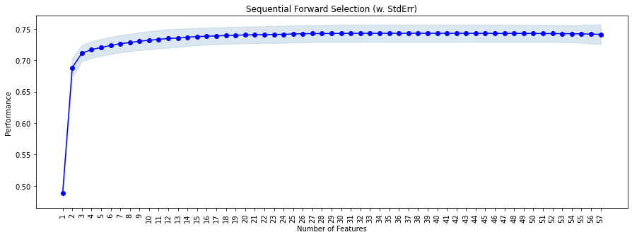

```python
# to plot the performance with addition of each feature
from mlxtend.plotting import plot_sequential_feature_selection as plot_sfs

fig1 = plot_sfs(sfs.get_metric_dict(), kind="std_err", figsize=(15, 5))
plt.title("Sequential Forward Selection (w. StdErr)")
plt.xticks(rotation=90)
plt.show()
```

Performance increase until 20 features, then asymptotes!

```python
reg = LinearRegression()

# Build step forward feature selection
sfs = SFS(
    reg,
    k_features=20,
    forward=True,
    floating=False,
    scoring="r2",
    n_jobs=-1,
    verbose=2,
    cv=5,
)

# Perform SFFS
sfs = sfs.fit(x_train, y_train)
```

[output not shown]

[output cut: 44 more lines]

[output not shown]

```python
# let us select the features which are important
feat_cols = list(sfs.k_feature_idx_)
print(feat_cols)
```

```
[0, 1, 3, 4, 5, 6, 7, 8, 9, 11, 14, 17, 21, 24, 28, 42, 43, 45, 51, 53]
```

```python
# let us look at the names of the important features
x_train.columns[feat_cols]
```

```
Index(['Year', 'Kilometers_Driven', 'Engine', 'Power', 'Seats', 'New_Price',
       'Location_Bangalore', 'Location_Chennai', 'Location_Coimbatore',
       'Location_Hyderabad', 'Location_Kolkata', 'Fuel_Type_Diesel',
       'Transmission_Manual', 'Owner_Type_Third', 'Make_Chevrolet',
       'Make_Mahindra', 'Make_Maruti', 'Make_Mini', 'Make_Skoda', 'Make_Tata'],
      dtype='object')
```

```python
x_train_final = x_train[x_train.columns[feat_cols]] # sklear model using those features only
```

```python
# Creating new x_test with the same 10 variables that we selected for x_train
x_test_final = x_test[x_train_final.columns]
```

```python
# Fitting linear model
lin_reg_model2 = LinearRegression()
lin_reg_model2.fit(x_train_final, y_train)

# model performance on train set
print("Training Performance\n")
lin_reg_model2_train_perf = model_performance_regression(
    lin_reg_model2, x_train_final, y_train
)
lin_reg_model2_train_perf

# model performance on test set
print("Test Performance\n")
lin_reg_model2_test_perf = model_performance_regression(
    lin_reg_model2, x_test_final, y_test
)
lin_reg_model2_test_perf
```

```
Training Performance

Test Performance
```

|  | RMSE | MAE | R-squared | Adj. R-squared | MAPE |
| --- | --- | --- | --- | --- | --- |
| 0 | 0.177629 | 0.121908 | 0.748408 | 0.746073 | inf |

```python
# training performance comparison

models_train_comp_df = pd.concat(
    [lin_reg_model_train_perf.T, lin_reg_model2_train_perf.T], axis=1,
)

models_train_comp_df.columns = [
    "Linear Regression sklearn",
    "Linear Regression sklearn (SFS features)",
]

print("Training performance comparison:")
models_train_comp_df
```

```
Training performance comparison:
```

|  | Linear Regression sklearn | Linear Regression sklearn (SFS features) |
| --- | --- | --- |
| RMSE | 0.176245 | 0.178289 |
| MAE | 0.121536 | 0.123043 |
| R-squared | 0.748876 | 0.743016 |
| Adj. R-squared | 0.746023 | 0.742000 |
| MAPE | inf | inf |

```python
# test performance comparison

models_test_comp_df = pd.concat(
    [lin_reg_model_test_perf.T, lin_reg_model2_test_perf.T], axis=1,
)

models_test_comp_df.columns = [
    "Linear Regression sklearn",
    "Linear Regression sklearn (SFS features)",
]

print("Test performance comparison:")
models_test_comp_df
```

```
Test performance comparison:
```

|  | Linear Regression sklearn | Linear Regression sklearn (SFS features) |
| --- | --- | --- |
| RMSE | 0.175143 | 0.177629 |
| MAE | 0.120284 | 0.121908 |
| R-squared | 0.755399 | 0.748408 |
| Adj. R-squared | 0.748816 | 0.746073 |
| MAPE | inf | inf |

Insights/Conclusions/Key takeaways:

1) A predictive model based on linear regression analysis has been built which shows a R2 of ~ 0.75 on training data

3) Based on feature selection, other important features has been evaluated is from categorical variables such as Location - Bangalore, Chennai, Coimbatore, Hyderabad, Kolkata & fuel type- diesel.

5) Make of the car is another important information used for the model. Ignoring this reduced R2 by almost 4%. Some of the important make was Chevrolet, Mahindra, Maruti, Tata, etc.

6) Model of the car was also tested as separate variable which was leading to >200 additional columns but R2 improved on test data was not much. Train data R2 did jump to 83% suggesting there is a overfitting. Hence, it was not considered for final model.

7) Log transformation was performaned on heavily skewed coluns which improved R2 by almost 8%!

7) Overall, presence of many outliers in price column is likely leading to lower R2 but it not suggested to remove so many outliers as it contains valuable information related to genuine expensive cars.